# t4cp1

## Dados

Os dados utilizados para esta análise representam avaliações de usuários para diversos filmes. As avaliações recebem notas que vão de 0 a 5, sendo 5 a melhor nota.

Para esta tarefa utilizaremos as opniões dedicadas à trilogia O poderoso chefão(The Godfather).

Para maiores informações basta acessar o [link](http://grouplens.org/datasets/movielens/latest/) do dataset.

```r
  ratings = read.csv("ml-latest-small/ratings.csv")
  movies = read.csv("ml-latest-small/movies.csv")
  data = merge(movies, ratings)

  godfather.ids <- c("858", "1221", "2023")
  data.filtered = data %>%
    filter(movieId %in% godfather.ids)
```

### Qual filme há melhor avaliação?

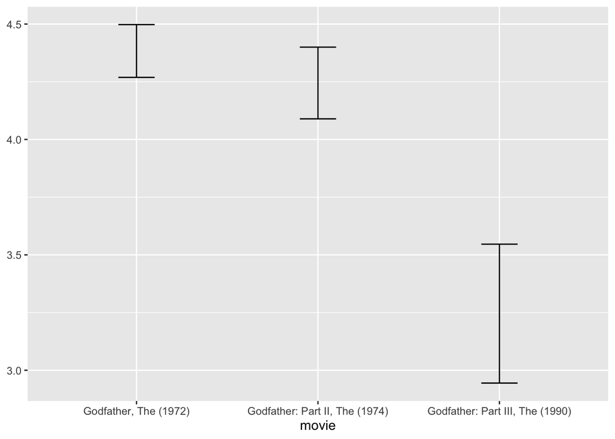

```r
  gf1 = data.filtered %>% filter(movieId == 858)
  gf2 = data.filtered %>% filter(movieId == 1221)
  gf3 = data.filtered %>% filter(movieId == 2023)

  gf1.boot = bootstrap(gf1, mean(rating), R = 10000)
  gf1.limits = CI.bca(gf1.boot, probs = c(0.025, .975))
  row.names(gf1.limits) = c("Godfather, The (1972)")

  gf2.boot = bootstrap(gf2, mean(rating), R = 10000)
  gf2.limits = CI.bca(gf2.boot, probs = c(.025, .975))
  row.names(gf2.limits) = c("Godfather: Part II, The (1974)")

  gf3.boot = bootstrap(gf3, mean(rating), R = 10000)
  gf3.limits = CI.bca(gf3.boot, probs = c(.025, .975))
  row.names(gf3.limits) = c("Godfather: Part III, The (1990)")

  df = data.frame(rbind(gf1.limits,
                        gf2.limits,
                        gf3.limits))

  df$movie = row.names(df)

  df %>%
  ggplot(aes(x = movie, ymin = X2.5., ymax = X97.5.)) +
  geom_errorbar(width = .2)
```

Após aplicar a técnica de bootstrap na nossa amostra, podemos dizer, baseado no gráfico acima, que o filme *The Godfather: Part III* obteve pior avaliação quando comparado aos dois episódios anteriores. Quando aos episódios *The Godfather: Part I* e *The Godfather: Part II* não podemos afirmar qual teve melhor avaliação, pelo fato que que o valor médio das avaliações desses dois se encontram em intervalos que se interseccionam.

### Qual filme tem maior variação nas notas atribuídas?

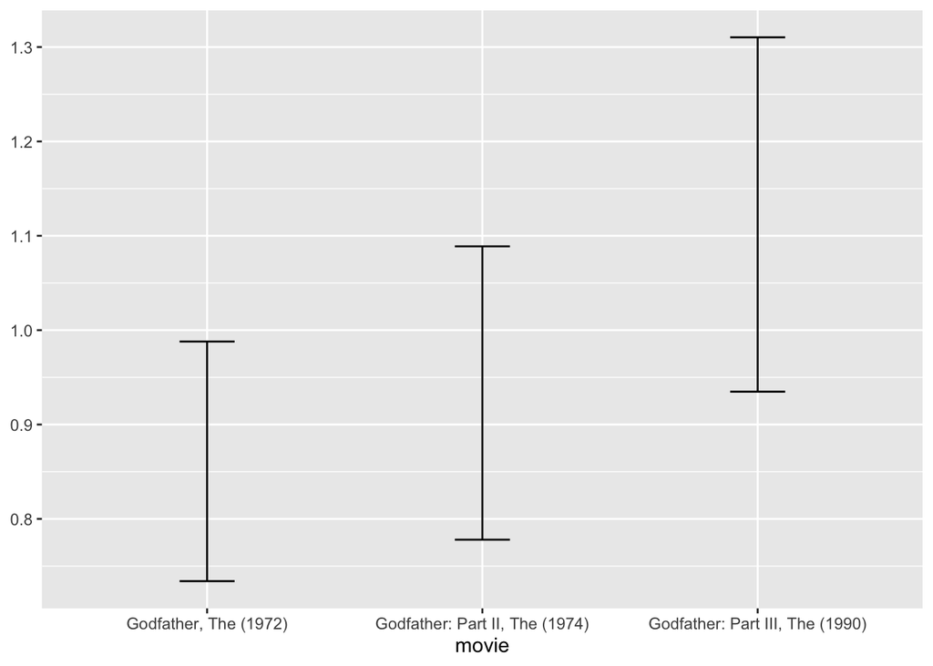

```r
  gf1.sd = bootstrap(gf1, sd(rating), R = 10000)
  gf1.limits = CI.bca(gf1.sd, probs = c(0.025, .975))
  row.names(gf1.limits) = c("Godfather, The (1972)")

  gf2.sd = bootstrap(gf2, sd(rating), R = 10000)
  gf2.limits = CI.bca(gf2.sd, probs = c(.025, .975))
  row.names(gf2.limits) = c("Godfather: Part II, The (1974)")

  gf3.sd = bootstrap(gf3, sd(rating), R = 10000)
  gf3.limits = CI.bca(gf3.sd, probs = c(.025, .975))
  row.names(gf3.limits) = c("Godfather: Part III, The (1990)")

  df = data.frame(rbind(gf1.limits,
                        gf2.limits,
                        gf3.limits))

  df$movie = row.names(df)

  df %>%
  ggplot(aes(x = movie, ymin = X2.5., ymax = X97.5.)) +
  geom_errorbar(width = .2)
```

Utilizando o desvio padrão das notas dos três episódios, não podemos concluir qual filme tem maior variação, pois os intervalos de confiança para o desvio padrão das notas de cada um deles se interseccionam entre si.

## Quantidade de gêneros influencia a classificação?

Criaremos uma nova coluna para cada entrada para indicar a quantos gêrenos cada título abrange.

```r
sum_genres = mutate(data, total_genres = str_count(data$genres, "\\|") + 1)
summary(sum_genres$total_genres)
```

```
##    Min. 1st Qu.  Median    Mean 3rd Qu.    Max.
##   1.000   2.000   3.000   2.676   3.000  10.000
```

```r
distincts = sum_genres %>%
  select(total_genres) %>%
  distinct()
show(distincts)
```

```
##   total_genres
## 1            5
## 2            3
## 3            2
## 4            1
## 5            4
## 6            6
## 7            7
## 8            8
## 9           10
```

Observando os valores da nova coluna, temos que a quantidade de gêneros para um só título varia de 1 a 10, não possuindo nenhum título com 9 gêneros.

Agora vamos aplicar mais uma vez a técnica de bootstrap a fim de calcular a mediana das avaliações para cada quantidade possível de gêneros simultâneos para um mesmo título.

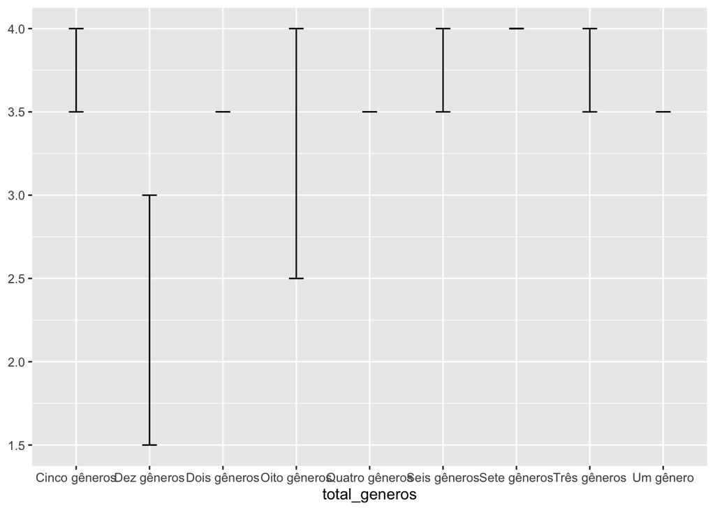

```r
  rvalue = 1000
  ic = c(0.025, .975)
  genres1.boot = bootstrap(filter(sum_genres, total_genres == 1), median(rating), R = rvalue)
  genres1.limits = CI.percentile(genres1.boot, probs = ic)
  row.names(genres1.limits) = c("Um gênero")

  genres2.boot = bootstrap(filter(sum_genres, total_genres == 2), median(rating), R = rvalue)
  genres2.limits = CI.percentile(genres2.boot, probs = c(0.025, .975))
  row.names(genres2.limits) = c("Dois gêneros")

  genres3.boot = bootstrap(filter(sum_genres, total_genres == 3), median(rating), R = rvalue)
  genres3.limits = CI.percentile(genres3.boot, probs = c(0.025, .975))
  row.names(genres3.limits) = c("Três gêneros")

  genres4.boot = bootstrap(filter(sum_genres, total_genres == 4), median(rating), R = rvalue)
  genres4.limits = CI.percentile(genres4.boot, probs = c(0.025, .975))
  row.names(genres4.limits) = c("Quatro gêneros")

  genres5.boot = bootstrap(filter(sum_genres, total_genres == 5), median(rating), R = rvalue)
  genres5.limits = CI.percentile(genres5.boot, probs = c(0.025, .975))
  row.names(genres5.limits) = c("Cinco gêneros")

  genres6.boot = bootstrap(filter(sum_genres, total_genres == 6), median(rating), R = rvalue)
  genres6.limits = CI.percentile(genres6.boot, probs = c(0.025, .975))
  row.names(genres6.limits) = c("Seis gêneros")

  genres7.boot = bootstrap(filter(sum_genres, total_genres == 7), median(rating), R = rvalue)
  genres7.limits = CI.percentile(genres7.boot, probs = c(0.025, .975))
  row.names(genres7.limits) = c("Sete gêneros")

  genres8.boot = bootstrap(filter(sum_genres, total_genres == 8), median(rating), R = rvalue)
  genres8.limits = CI.percentile(genres8.boot, probs = c(0.025, .975))
  row.names(genres8.limits) = c("Oito gêneros")

  genres10.boot = bootstrap(filter(sum_genres, total_genres == 10), median(rating), R = rvalue)
  genres10.limits = CI.percentile(genres10.boot, probs = c(0.025, .975))
  row.names(genres10.limits) = c("Dez gêneros")

  df = data.frame(rbind(genres1.limits,
                      genres2.limits,
                      genres3.limits,
                      genres4.limits,
                      genres5.limits,
                      genres6.limits,
                      genres7.limits,
                      genres8.limits,
                      genres10.limits))

  df$total_generos = row.names(df)

  df %>%
  ggplot(aes(x = total_generos, ymin = X2.5., ymax = X97.5.)) +
  geom_errorbar(width = .2)
```

A partir do gráfico gerado vemos que os filmes que se encaixam em sete gêneros tem como mediana para notas obtidas igual a 4.0, nota melhor que os filmes com apenas um gênero os quais obtiveram como mediana para notas obtidas o valor 3.5.